# CRC Stock SVM

Carlos Pelayo

10/11/2019

# 1 Introduction

This is an implementation of a support vector machine designed to identify short-term stock price changes, based on previous stock parameters: open, low, high, close, volume

## 1.1 Stock selected for this exercise:

## 1.2 get data:

```r
crcData = read.csv('CRC.csv')
attach(crcData)
# set up data frame
crcDataFrame = data.frame(open=price.open, high=price.high,
        low=price.low, close=price.adjusted,volume= volume/10000,oil=oil.price,change = direction)
head(crcDataFrame)
```

```
##    open  high    low close volume    oil change
## 1 39.94 40.99 37.750 39.30 200.37 71.340      U
## 2 39.84 40.29 37.900 38.50 136.20 71.780      D
## 3 38.84 39.48 37.860 39.36  86.22 71.920      D
## 4 38.79 38.96 36.500 37.51 137.20 69.740      D
## 5 35.97 36.93 35.511 35.97 161.65 68.674      D
## 6 36.48 36.93 34.690 35.10 117.78 69.216      D
```

```r
tail(crcDataFrame)
```

```
##      open   high  low close volume   oil change
## 242  9.99 10.290 9.77 10.20 188.10 55.91      D
## 243 10.27 10.660 9.66  9.75 213.30 54.07      D
## 244  9.70 10.024 9.11  9.13 334.55 53.62      D
## 245  9.02  9.290 8.40  9.07 380.58 52.64      D
## 246  9.13  9.270 8.67  8.70 261.00 52.45      D
## 247  8.80  9.020 8.47  8.51 338.23 52.81      D
```

```r
remove(crcData)
```

```r
levels(direction)
```

```
## [1] "D" "N" "U"
```

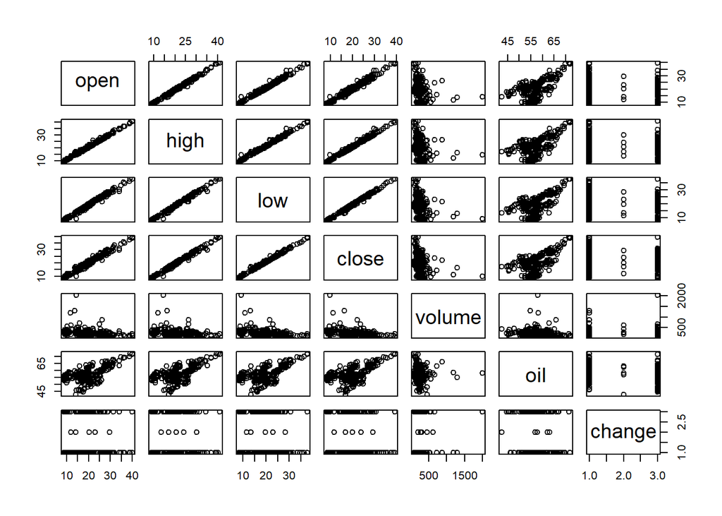

```r
plot(crcDataFrame)
```

## 1.3 classification model, categorical response

### 1.3.1 traditional interface:

```r
x <- subset(crcDataFrame[1:231,], select = -change)
y <- crcDataFrame[1:231,]$change

model_test<- svm(x,y)

print(model_test)
```

```
##
## Call:
## svm.default(x = x, y = y)
##
##
## Parameters:
##    SVM-Type:  C-classification
##  SVM-Kernel:  radial
##        cost:  1
##
## Number of Support Vectors:  213
```

```r
summary(model_test)
```

```
##
## Call:
## svm.default(x = x, y = y)
##
##
## Parameters:
##    SVM-Type:  C-classification
##  SVM-Kernel:  radial
##        cost:  1
##
## Number of Support Vectors:  213
##
##  ( 100 108 5 )
##
##
## Number of Classes:  3
##
## Levels:
##  D N U
```

## 1.4 how well did the model fit?

```r
pred <- predict(model_test, x)

# Check accuracy:
table(pred, y)
```

```
##     y
## pred  D  N  U
##    D 79  4 47
##    N  0  0  0
##    U 38  1 62
```

## 1.5 decision values

```r
# compute decision values and probabilities:
pred <- predict(model_test, x, decision.values = TRUE)
attr(pred, "decision.values")[1:7,]
```

```
##          U/D      U/N       D/N
## 1 -0.7419965 1.011729 0.9929068
## 2 -0.9275862 1.019296 1.0002760
## 3 -1.0206311 1.012101 1.0002407
## 4 -1.0000519 1.037219 1.0046479
## 5 -1.0310572 1.040464 1.0003988
## 6 -1.0810325 1.058031 1.0045895
## 7 -1.0774070 1.060046 1.0002359
```

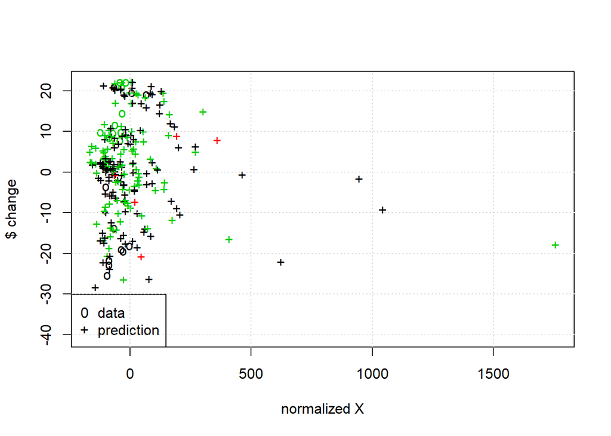

```r
# visualize (classes by color, SV by crosses):
plot(cmdscale(dist(crcDataFrame[,-7])),
     col = as.integer(crcDataFrame[,7]),xlab="normalized X", ylab = "$ change",
     pch = c("o","+")[1:200 %in% model_test$index + 1])
legend('bottomleft',c('data','prediction'),pch=c('0','+'))
grid()
```

# 2 train and test set:

```r
pctTrain=0.66
#nObs = length(x[,1])
nObs=231
nTrain = round(pctTrain*nObs,0)
TrainSetIndex = 1:nTrain



# or ?
#scramble=sample(1:nObs)
#TrainSetIndex=scramble[1:nTrain]
#TestSetIndex= scramble[(nTrain+1):nObs]
```

## 2.1 set up training set, test set

```r
# first the training set

XtrainSet = crcDataFrame[TrainSetIndex,-7]
YtrainSet = crcDataFrame$change[TrainSetIndex]
```

## 2.2 get the model from training set..

```r
model_train<- svm(XtrainSet, YtrainSet)
print(model_train)
```

```
##
## Call:
## svm.default(x = XtrainSet, y = YtrainSet)
##
##
## Parameters:
##    SVM-Type:  C-classification
##  SVM-Kernel:  radial
##        cost:  1
##
## Number of Support Vectors:  139
```

```r
summary(model_train)
```

```
##
## Call:
## svm.default(x = XtrainSet, y = YtrainSet)
##
##
## Parameters:
##    SVM-Type:  C-classification
##  SVM-Kernel:  radial
##        cost:  1
##
## Number of Support Vectors:  139
##
##  ( 64 71 4 )
##
##
## Number of Classes:  3
##
## Levels:
##  D N U
```

## 2.3 now the test set..

```r
XtestSet = crcDataFrame[(nTrain:nObs),-7]
YtestSet = crcDataFrame$change[nTrain:nObs]
```

## 2.4 and evaluate with the test data

```r
pred2 <- predict(model_train, XtestSet)
# And the accuracy..

table(pred2, YtestSet)
```

```
##      YtestSet
## pred2  D  N  U
##     D 11  1 15
##     N  0  0  0
##     U 27  0 26
```

## 2.5 tune

```r
stockTuned <- tune.svm(XtrainSet, YtrainSet, gamma = 2^(-1:1), cost = 2^(-1:6))

summary(stockTuned)
```

```
##
## Parameter tuning of 'svm':
##
## - sampling method: 10-fold cross validation
##
## - best parameters:
##  gamma cost
##    0.5    2
##
## - best performance: 0.4220833
##
## - Detailed performance results:
##    gamma cost     error dispersion
## 1    0.5  0.5 0.4879167 0.09833588
## 2    1.0  0.5 0.5012500 0.12647357
## 3    2.0  0.5 0.5391667 0.10955860
## 4    0.5  1.0 0.4487500 0.13969281
## 5    1.0  1.0 0.4345833 0.09501563
## 6    2.0  1.0 0.4800000 0.06613795
## 7    0.5  2.0 0.4220833 0.12124053
## 8    1.0  2.0 0.4541667 0.08906233
## 9    2.0  2.0 0.5137500 0.11324428
## 10   0.5  4.0 0.4541667 0.11344765
## 11   1.0  4.0 0.5200000 0.09124059
## 12   2.0  4.0 0.5137500 0.12951789
## 13   0.5  8.0 0.4808333 0.09928759
## 14   1.0  8.0 0.5337500 0.15212550
## 15   2.0  8.0 0.5141667 0.13759396
## 16   0.5 16.0 0.5008333 0.09632122
## 17   1.0 16.0 0.5012500 0.13866718
## 18   2.0 16.0 0.4675000 0.14253276
## 19   0.5 32.0 0.5212500 0.11314885
## 20   1.0 32.0 0.4558333 0.13418708
## 21   2.0 32.0 0.4933333 0.13865536
## 22   0.5 64.0 0.5150000 0.12081258
## 23   1.0 64.0 0.4483333 0.10606965
## 24   2.0 64.0 0.4870833 0.13886736
```

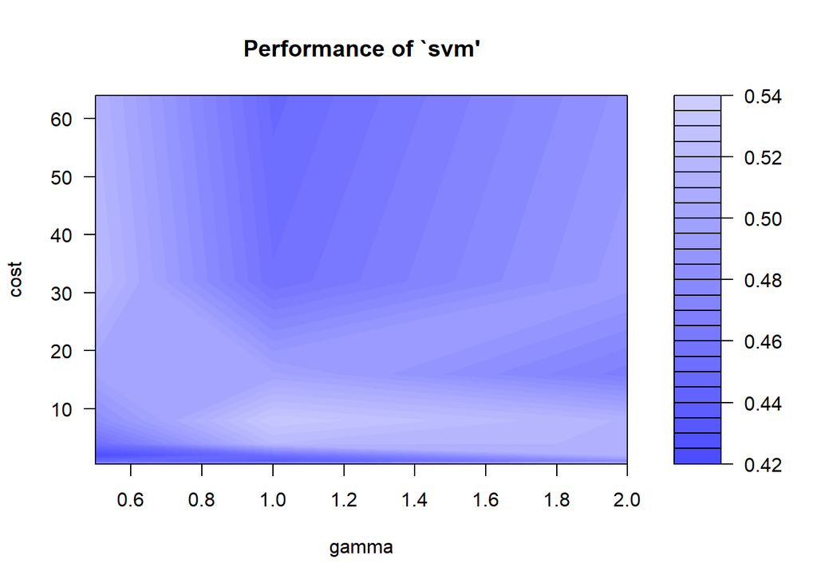

```r
plot(stockTuned)
```

```r
#use optimized parameters...
model_tuned <- svm(XtrainSet, YtrainSet, gamma=0.5, cost=2)

print(model_tuned)
```

```
##
## Call:
## svm.default(x = XtrainSet, y = YtrainSet, gamma = 0.5, cost = 2)
##
##
## Parameters:
##    SVM-Type:  C-classification
##  SVM-Kernel:  radial
##        cost:  2
##
## Number of Support Vectors:  133
```

```r
summary(model_tuned)
```

```
##
## Call:
## svm.default(x = XtrainSet, y = YtrainSet, gamma = 0.5, cost = 2)
##
##
## Parameters:
##    SVM-Type:  C-classification
##  SVM-Kernel:  radial
##        cost:  2
##
## Number of Support Vectors:  133
##
##  ( 62 67 4 )
##
##
## Number of Classes:  3
##
## Levels:
##  D N U
```

```r
pred3 <- predict(model_tuned, XtestSet)
# And the accuracy..

table(pred3, YtestSet)
```

```
##      YtestSet
## pred3  D  N  U
##     D  9  1 13
##     N  0  0  0
##     U 29  0 28
```

```r
pred= predict(model_tuned,XtestSet,decision.values = TRUE)
attr(pred,"decision.values")[1:20,]
```

```
##            U/D       U/N       D/N
## 152 -0.9157902 0.9704485 0.9997971
## 153  1.5304616 1.0140647 1.1141414
## 154  1.3936035 1.0719282 1.0801726
## 155  1.1866151 1.0117564 1.0224483
## 156  1.1241021 1.0307353 1.0245842
## 157  1.3148018 1.0326293 1.0297490
## 158  1.1821812 1.0072975 1.0303197
## 159  1.2945041 1.0474633 1.0622493
## 160  1.5837410 1.0287799 1.0634921
## 161  0.9283706 1.1526710 1.1273877
## 162  0.8121179 1.0167512 1.0271479
## 163  0.9304179 1.0554998 1.0498134
## 164  1.2661699 1.0265593 1.0497559
## 165  1.3806506 1.0107033 1.0476118
## 166  1.1148585 1.0246622 1.0461030
## 167  1.0736333 1.1549518 1.1162588
## 168  1.4115904 1.0313417 1.0628917
## 169  1.3512367 0.9923639 1.0392821
## 170  1.2779611 1.1294784 1.1163441
## 171  1.6593428 1.0646993 1.0951893
```

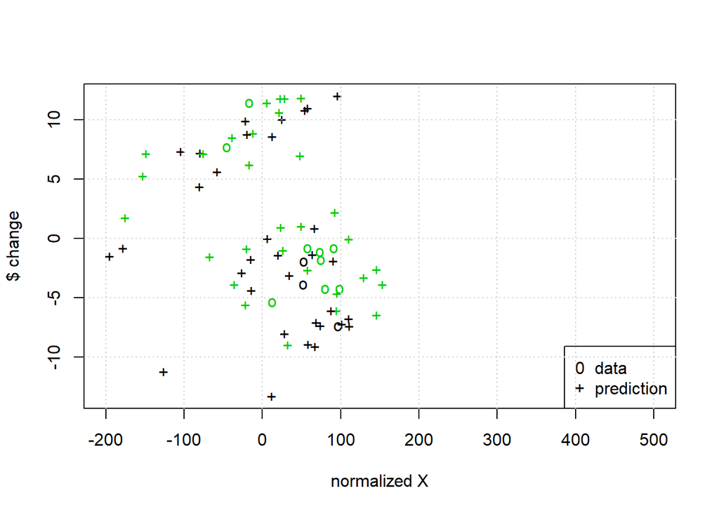

```r
plot(cmdscale(dist(XtestSet)),
     col = as.integer(YtestSet),xlab="normalized X", ylab = "$ change",
     pch = c("o","+")[1:200 %in% model_tuned$index + 1],xlim = c(-200,500))
legend('bottomright',c('data','prediction'),pch=c('0','+'))
grid()
```

```r
XtrainSet2 = crcDataFrame[232:247,-7]
YtrainSet2=crcDataFrame$change[232:247]


pred4 <- predict(model_tuned, XtrainSet2)

table(pred4,YtrainSet2)
```

```
##      YtrainSet2
## pred4  D  N  U
##     D 13  0  1
##     N  0  0  0
##     U  2  0  0
```

#SVM Assignment

## 2.6 complete an rmarkdown file on the stock you selected.

You will turn in the URL for your github accout that has the repo for this assignment.

### 2.6.1 Identify the stock you use for this assignment.

Why did you choose this particular stock?

I chose the California Resources Stock becaused fo the variability from day to day. It has also seen pretty steep rises and falls over the last year.

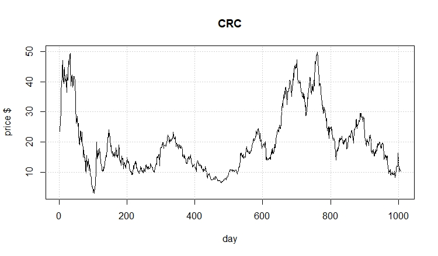

```r
knitr::include_graphics("CRC Price Graph.jpeg")
```

### 2.6.2 Use this template to get the SVM:

1. Training and Test sets:

I chose to use chronological data observations. I believe that because the stock I chose is of an energy company, that some trends could be market related or seasonal. I used 2/3 of my data set to train the SVM. I chose something large enough to include steep climbs and drops.

2. How well did the SVM do?:

```r
table(pred2, YtestSet)
```

```
##      YtestSet
## pred2  D  N  U
##     D 11  1 15
##     N  0  0  0
##     U 27  0 26
```

```r
table(pred3, YtestSet)
```

```
##      YtestSet
## pred3  D  N  U
##     D  9  1 13
##     N  0  0  0
##     U 29  0 28
```

### 2.6.3 Evaluate SVM performance

1. Did you exmine using other than the ‘open’, ‘low’, ‘high’, ‘close’ prices and volume as predictors?

I include oil price in my model. Since, CRC is an oil and gas company I figured that oil price could have a significant influence on the stock price.

2. Use the SVM you developed to predict stock moves on 16 - 20 Sept. 2019. Compute the ROI assuming the SVM identifies an opportunity, (for example use around $1000 on each of the SVM predictions)

```r
table(pred4,YtrainSet2)
```

```
##      YtrainSet2
## pred4  D  N  U
##     D 13  0  1
##     N  0  0  0
##     U  2  0  0
```

I tested the model with the last two weeks of data, so from 9/13/2019 to 10/7/2019. The model correctly predicted a decrease in stock price 92% of the time. It didn’t predict anything else right.

3. Would you put your own $$ in this SVM?

I would not invest my own money in this SVM. The predictions in increase are not correct enough of the time for me to make any money.Since I do not have CRC stock at the moment, so shorting the stock could possible go better than purchasing stock, but it is still to big a risk for me to invest using the SVM.